# Regression Splines II

Andrew Zieffler

December 03, 2020

**These notes draw from Berk (2016).**

```r
# Load libraries
library(broom)
library(educate)
library(patchwork)
library(splines)
library(tidyverse)
```

In the last set of notes we fitted a cubic B-spline model to the Tokyo water data with knots defined at 1980 and 1992. Recall that the data in *tokyo-water-use.csv* were collected due to concerns about the provision of potable water to large metropolitan areas, which is a potential problem resulting from human-induced climate change. The data consist of 27 years worth of residential water use (measured in 1000s of cubic feet).

```r
# Import data
tokyo = read_csv("../data/tokyo-water-use.csv")

# Fit cubic spline using B-spline basis
bs.1 = lm(water_use ~ 1 + bs(year, knots = c(1980, 1992)), data = tokyo)
```

## Choosing Knots

It is important to know that the number of knots chosen and their placement is a big deal. Differing numbers of knots and their values will affect the model! To this point, we have selected the knot values for the model, namely 1980 and 1992. We initially chose these values from a visual inspection of the data.

Like many other endeavors in modeling, the analyst should choose both the number of knots and their values *before looking at the data*. This, ideally would be done using substantive knowledge to include more knots where *f(x)* changes the most rapidly, and placing fewer knots where the function is more stable.

In practice, one of two things typically happens. Either the analyst chooses knot placement by combining their substantive knowledge along with some data snooping (looking at the data), or the knots are placed in a uniform manner across the data (e.g., at the 20th, 40th, 60th, and 80th percentiles).

When the knots are placed in a uniform manner, rather than choosing the values for the knots, the analyst chooses the *df* for the model. This can be specified by using the `df=` argument rather than `knots=` argument in the `bs()` function. We set this argument to $D + k$, where *D* is the degree of the polynomial fitted, and *k* is the desired number of interior knots. For example, if we wanted a cubic polynomial spline with two interior knots, we would set `df=5`.

```r
# Fit cubic spline using B-spline basis with two uniformly distributed interior knots
bs.2 = lm(water_use ~ 1 + bs(year, df = 5), data = tokyo)
```

The plot below shows the fitted spline models for both models. In the second model, the interior knots were chosen by the software, which uniformly placed them at the 33rd and 66th percentiles, respectively.

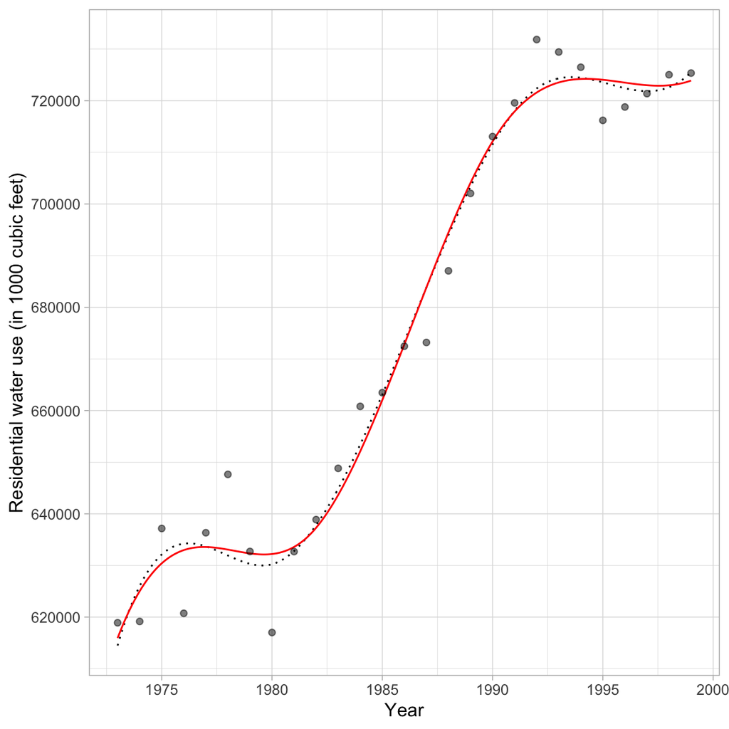

```r
# Set up plot data
plot_data = data.frame(
  year = seq(from = 1973, to = 1999, by = 0.1)
) %>%
  mutate(
    yhat_choose = predict(bs.1, newdata = .),
    yhat_unif = predict(bs.2, newdata = .)
  )


# Plot fitted lines for both spline models
ggplot(data = plot_data, aes(x = year, y = yhat_choose)) +
  geom_line(color = "black", linetype = "dotted")  +
  geom_line(aes(y = yhat_unif), color = "red") +
  geom_point(data = tokyo, aes(x = year, y = water_use), alpha = 0.5) +
  theme_light() +
  scale_x_continuous(
    name = "Year",
    breaks = seq(from = 1970, to = 2005, by = 5)
    ) +
  scale_y_continuous(
    name = "Residential water use (in 1000 cubic feet)",
    breaks = seq(from = 600000, to = 740000, by = 20000)
  )
```

The different knot placement resulted in a different fitted model. What happens if we choose a different number of knots? The plot below shows the fitted models based on differing numbers of knots.

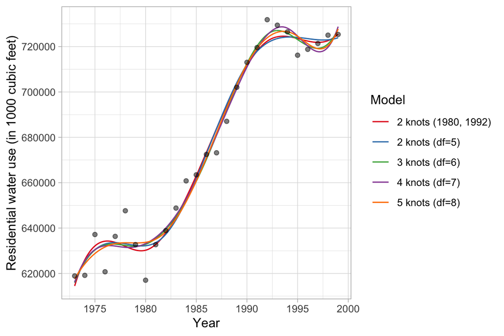

Plot of the predicted water use over time using five different B-spline models.

As with the knot placement, models with different numbers of interior knots produce different fitted models. How do you choose the number of knots? One way is to try out models with different number of knots and see which fitted model produces the best-looking and interpretable curve.

Another way to pick the number of knots is to treat this as a model selection problem. You could fit models with different numbers of knots and then use cross-validation or model-evidence methods to select the number of knots to use.

```r
# Load library
library(AICcmodavg)

# Obtain model evidence
aictab(
  cand.set = list(bs.1, bs.2, bs.3, bs.4, bs.5),
  modnames = c("2 knots (1980, 1992)", "2 knots (df=5)", "3 knots (df=6)", "4 knots (df=7)", "5 knots (df=8)")
  )
```

```
##
## Model selection based on AICc:
##
##                       K   AICc Delta_AICc AICcWt Cum.Wt      LL
## 2 knots (1980, 1992)  7 570.64       0.00   0.53   0.53 -275.37
## 2 knots (df=5)        7 572.25       1.61   0.24   0.77 -276.18
## 3 knots (df=6)        8 572.41       1.77   0.22   0.99 -274.21
## 4 knots (df=7)        9 578.73       8.08   0.01   1.00 -275.07
## 5 knots (df=8)       10 584.03      13.39   0.00   1.00 -275.14
```

Here the model with the most empirical evidence (given the data and candidate set of models) has two interior knots at 1980 and 1992. There is also some empirical evidence for the model having two knots uniformly spread through the data and for the model having three interior knots uniformly spread through the data. To further evaluate them, we will examine their residuals.

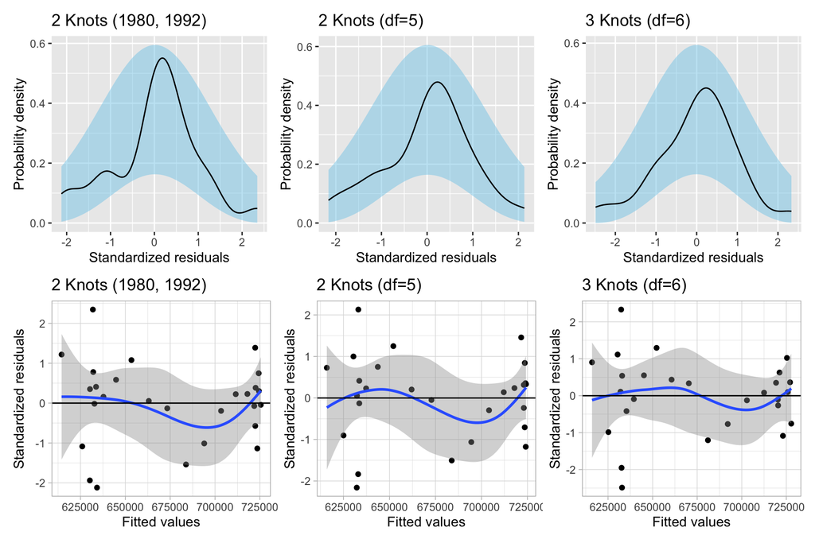

Residual plots for the three candidate B-spline models.

All three models show reasonable fit to the normality assumption (at least to marginal normality). The assumption that the conditional mean residual is zero (for all fitted values) and homogeneity of variance also seems reasonable for all three models. Based on this and the rule of parsimony, we will adopt the model with two interior knots at 1980 and 1992—having knots at 1980 and 1992 is easier to write about than having knots at 1981.6 (33rd percentile) and 1990.3 (66th percentile).

To determine the knot placement for the uniformly spread models, you can access the model’s attributes, specifically the `predvars` used in the model.

```r
attr(bs.2$terms, "predvars")
```

```
## list(water_use, bs(year, degree = 3L, knots = c(`33.33333%` = 1981.66666666667,
## `66.66667%` = 1990.33333333333), Boundary.knots = c(1973, 1999
## ), intercept = FALSE))
```

Note that in this model interior knots were placed at 1981.67 (the 33rd percentile) and at 1990.3 (the 66.7th percentile). There were also boundary knots placed at 1973 and 1999. The interior knots could also be defined using the `quantile()` function and then called in the `knots=` argument of the `bs()` function.

```r
# Get knot placement
my_knots = quantile(tokyo$year, probs = c(1/3, 2/3))
my_knots
```

```
## 33.33333% 66.66667%
##  1981.667  1990.333
```

```r
# Fit model
bs.2.2 = lm(water_use ~ 1 + bs(year, knots = my_knots), data = tokyo)
```

Knot placement and choosing the number of knots is a difficult (and unsolved!) methodological problem and this gets worse with more than one predictor. With more than one predictor, you would have to select the knot placement and degrees of freedom for each predictor. In these cases we often take a very pragmatic approach and set the number of interior knots for all predictors to be a fixed value, say 3 or 4. Much of the methodological research to date suggests that most of the time choosing three to four interior knots results in reasonable fit for most situations.

### Graphical Uncertainty

Again, since the primary interpretational aid is the plot of the fitted values, if we want to include information about the uncertainty (and we should) it behooves us to include a confidence interval for the fitted spline model. And, given that the normality assumption seemed reasonable, we can produce confidence limits for our fitted model by adding/subtracting two SEs from the fitted value. We can do this using the same methodology we used to fit the envelope for piecewise models.

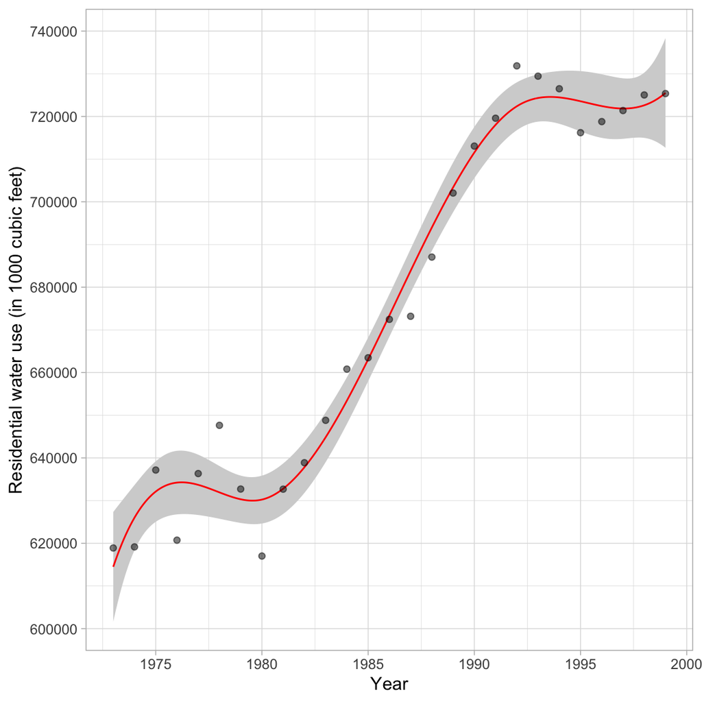

Plot of the predicted water use over time using a B-spline model in which the interior knots were defined at 1980 and 1992. The uncertainty, based on the pointwise confidence intervals, is also displayed.

```r
# Set up data for plotting
plot_data = data.frame(
  year = seq(from = 1973, to = 1999, by = 0.1)
)

# Compute fitted values and SEs
preds = predict(bs.1, newdata = plot_data, se.fit = TRUE)

# Add the fitted values, SEs, and limits to the plotting data
plot_data = plot_data %>%
  mutate(
    yhat = preds$fit,
    se = preds$se.fit,
    lower_limit = yhat - 2*se,
    upper_limit = yhat + 2*se
  )

# Plot
ggplot(data = plot_data, aes(x = year, y = yhat)) +
  geom_ribbon(aes(ymin = lower_limit, ymax = upper_limit), fill = "lightgrey") +
  geom_line(color = "red") +
  geom_point(data = tokyo, aes(x = year, y = water_use), alpha = 0.5) +
  theme_light() +
  scale_x_continuous(name = "Year", breaks = seq(from = 1970, to = 2005, by = 5)) +
  scale_y_continuous(
    name = "Residential water use (in 1000 cubic feet)",
    breaks = seq(from = 600000, to = 740000, by = 20000)
  )
```

Overall the uncertainty for the spline model is quite low. The exception is for extreme *x*-values, especially at the end-points. For those values the spline model indicates a severe amount of uncertainty. This large degree of uncertainty at the end-points is largely due to the model having too much flexibility at the exremes—a cubic model produces a lot of uncertainty at the extremes of the data.

## Natural Splines

Natural splines are similar to B-splines, except they have the additional constraint that the the function is linear at the boundaries (in the region where the predictor is smaller than the smallest knot and larger than the largest knot). This additional constraint generally makes the model more stable at the boundaries (especially when extrapolating) giving a smaller confidence envelope at the endpoints of the predictor.

To fit the natural spline we use the `ns()` function from the **splines** library. We can again specify the location of the knots using the `knots=` argument or the number of knots via the `df=` argument. For natural splines, however, we adjust the formula for the degrees of freedom to account for the linearity constraint at the extremes. We use:

$$\mathit{df} = D + k - 2$$

where *D* is the degree polynomial and *k* is the number of interior knots to use. To fit a cubic spline model with two internal knots, we use `df=3`. (We subtract two because of the linear boundary constraint at both ends of the data).

```r
# Fit natural spline model with two knots
ns.1 = lm(water_use ~ 1 + ns(year, df = 3), data = tokyo)

# Obtain knot locations
attr(ns.1$terms, "predvars")
```

```
## list(water_use, ns(year, knots = c(`33.33333%` = 1981.66666666667,
## `66.66667%` = 1990.33333333333), Boundary.knots = c(1973, 1999
## ), intercept = FALSE))
```

Here, the interior knots were uniformly distributed across the predictor. The knot locations are again at the 33.3rd and 66.7th percentiles of the `year` variable, namely 1981.7 and 1990.3. We could also have fitted the natural spline model specifying our interior knots at 1980 and 1992.

```r
# Fit natural spline model with two knots
ns.2 = lm(water_use ~ 1 + ns(year, knots = c(1980, 1992)), data = tokyo)

# Obtain knot locations
attr(ns.2$terms, "predvars")
```

```
## list(water_use, ns(year, knots = c(1980, 1992), Boundary.knots = c(1973,
## 1999), intercept = FALSE))
```

The plot of the fitted natural spline model with specified interior knots at 1980 and 1992 is shown below:

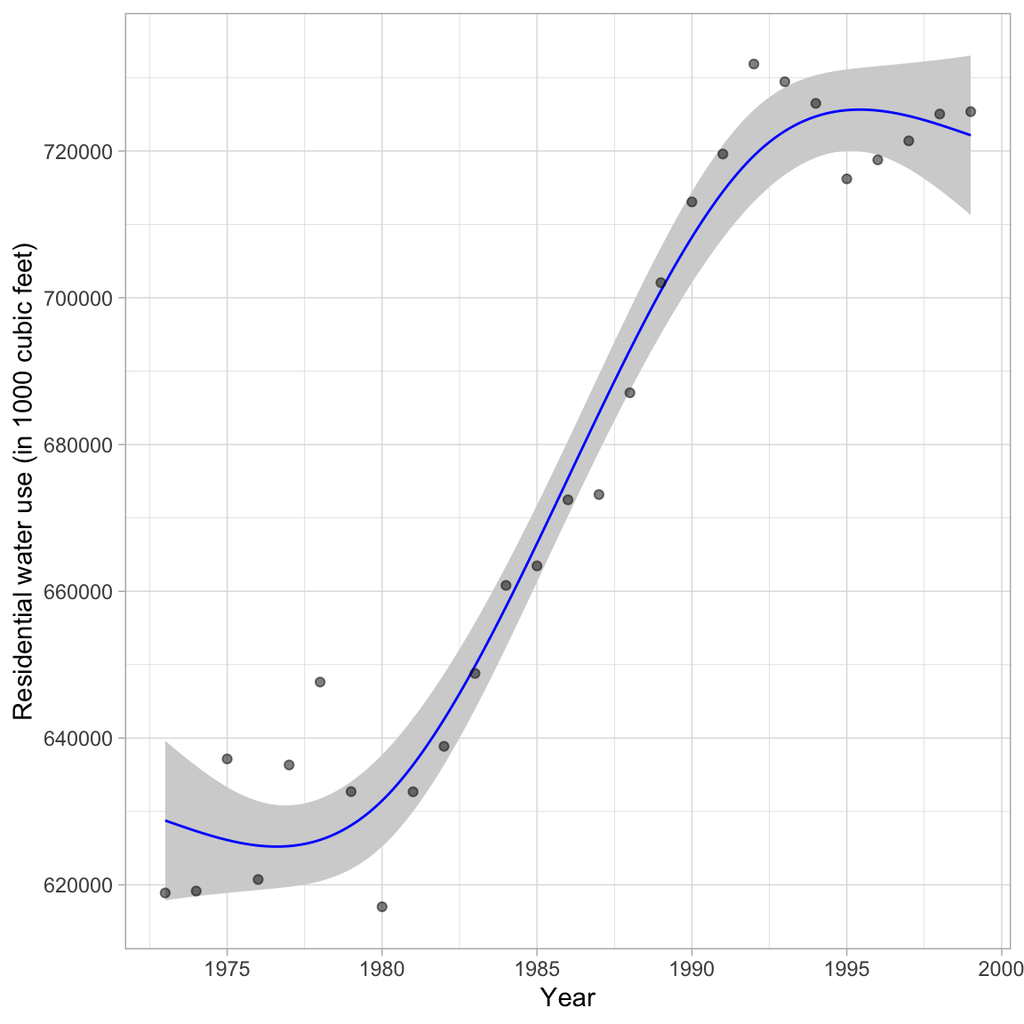

Plot of the predicted water use over time using a natural spline model in which the interior knots were defined at 1980 and 1992. The uncertainty, based on the pointwise confidence intervals, is also displayed.

```r
# Set up plotting data
plot_data_ns = data.frame(
  year = seq(from = 1973, to = 1999, by = 0.1)
)

# Compute fitted values and SEs
preds_ns = predict(ns.2, newdata = plot_data_ns, se.fit = TRUE)

# Add the fitted values, SEs, and limits to the plotting data
plot_data_ns = plot_data_ns %>%
  mutate(
    yhat = preds_ns$fit,
    se = preds_ns$se.fit,
    lower_limit = yhat - 2*se,
    upper_limit = yhat + 2*se
  )

# Plot
ggplot(data = plot_data_ns, aes(x = year, y = yhat)) +
  geom_ribbon(aes(ymin = lower_limit, ymax = upper_limit), fill = "lightgrey") +
  geom_line(color = "blue") +
  geom_point(data = tokyo, aes(x = year, y = water_use), alpha = 0.5) +
  theme_light() +
  scale_x_continuous(name = "Year", breaks = seq(from = 1970, to = 2005, by = 5)) +
  scale_y_continuous(
    name = "Residential water use (in 1000 cubic feet)",
    breaks = seq(from = 600000, to = 740000, by = 20000)
  )
```

The benefit in stability is seen in the boundary regions. Below, we will extrapolate the model and SEs to 1970 and 2005.

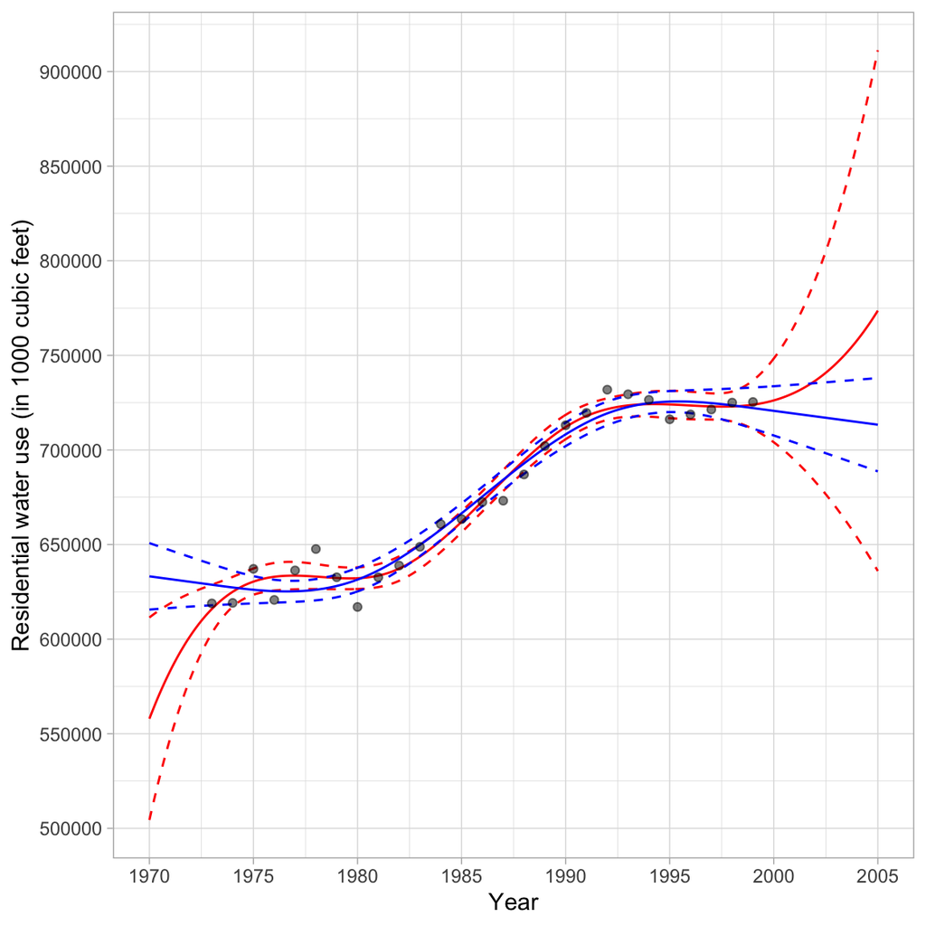

```r
# Set up data for plotting
plot_data_bs = data.frame(
  year = seq(from = 1970, to = 2005, by = 0.1)
)

# Compute fitted values and SEs
preds_bs = predict(bs.2, newdata = plot_data_bs, se.fit = TRUE)

# Add the fitted values, SEs, and limits to the plotting data
plot_data_bs = plot_data_bs %>%
  mutate(
    yhat = preds_bs$fit,
    se = preds_bs$se.fit,
    lower_limit = yhat - 2*se,
    upper_limit = yhat + 2*se
  )


plot_data_ns = data.frame(
  year = seq(from = 1970, to = 2005, by = 0.1)
)

# Compute fitted values and SEs
preds_ns = predict(ns.2, newdata = plot_data_ns, se.fit = TRUE)

# Add the fitted values, SEs, and limits to the plotting data
plot_data_ns = plot_data_ns %>%
  mutate(
    yhat = preds_ns$fit,
    se = preds_ns$se.fit,
    lower_limit = yhat - 2*se,
    upper_limit = yhat + 2*se
  )

# Plot
ggplot(data = plot_data_bs, aes(x = year, y = yhat)) +
  geom_line(color = "red") +
  geom_line(aes(y = lower_limit), color = "red", linetype = "dashed") +
  geom_line(aes(y = upper_limit), color = "red", linetype = "dashed") +
  geom_line(data = plot_data_ns, color = "blue") +
  geom_line(data = plot_data_ns, aes(y = lower_limit), color = "blue", linetype = "dashed") +
  geom_line(data = plot_data_ns, aes(y = upper_limit), color = "blue", linetype = "dashed") +
  geom_point(data = tokyo, aes(x = year, y = water_use), alpha = 0.5) +
  theme_light() +
  scale_x_continuous(name = "Year", breaks = seq(from = 1970, to = 2005, by = 5)) +
  scale_y_continuous(
    name = "Residential water use (in 1000 cubic feet)",
    breaks = seq(from = 400000, to = 900000, by = 50000)
  )
```

Past the boundary knots of 1973 and 1999, the B-spline model shows a great deal of uncertainty. The natural cubic spline shows smaller SEs (less uncertainty) for the same regions. You can also see the linearity constraint in the natural cubic spline model in these regions.

## References

Berk, R. (2016). *Statistical learning from a regression perspective* (2nd ed.). Springer.